# BME-336546-C06-Nonlinear classification (SVM and Random forest)

## Data loading

```python
from sklearn.metrics import RocCurveDisplay, ConfusionMatrixDisplay

import numpy as np
import pickle
import sys
import pandas as pd
import matplotlib as mpl
import seaborn as sns
import matplotlib.pyplot as plt
mpl.style.use(['ggplot'])
%matplotlib inline
plt.rcParams['axes.labelsize'] = 14
plt.rcParams['xtick.labelsize'] = 12
plt.rcParams['ytick.labelsize'] = 12
from sklearn.model_selection import StratifiedKFold
from sklearn.model_selection import train_test_split
from sklearn.preprocessing import StandardScaler
from tqdm import tqdm
from sklearn.linear_model import LogisticRegression
from sklearn.metrics import log_loss
from sklearn.pipeline import Pipeline
```

In this tutorial we would use data that you can find within `sklearn.datasets`. The chosen data are concentric circles.

```python
from sklearn.datasets import make_circles
X, y = make_circles(1000, factor=.1, noise=.2, random_state=336546)
```

As usual, we should split our data into training and testing sets:

```python
X_train, x_test, Y_train, y_test = train_test_split(X, y, test_size = 0.20, random_state = 10, stratify=y)
```

```python
def plot_radar(clf, clf_type):
    labels=np.array(['Accuracy', 'F1', 'PPV', 'Sensitivity', 'AUROC'])
    score_mat_train = np.stack((clf.cv_results_['mean_train_accuracy'], clf.cv_results_['mean_train_f1'],
                               clf.cv_results_['mean_train_precision'], clf.cv_results_['mean_train_recall'],
                               clf.cv_results_['mean_train_roc_auc']), axis=0)
    score_mat_val = np.stack((clf.cv_results_['mean_test_accuracy'], clf.cv_results_['mean_test_f1'],
                               clf.cv_results_['mean_test_precision'], clf.cv_results_['mean_test_recall'],
                               clf.cv_results_['mean_test_roc_auc']), axis=0)


    angles=np.linspace(0, 2*np.pi, len(labels), endpoint=False)

    angles=np.concatenate((angles,[angles[0]]))
    cv_dict = clf.cv_results_['params']
    fig=plt.figure(figsize=(18,14))
    if 'svm__gamma' in cv_dict[0]:
        new_list = [(i, item) for i, item in enumerate(cv_dict) if
                    item["svm__kernel"] == clf_type[0] and item["svm__gamma"] == clf_type[1]]
    else:
        new_list = [(i, item) for i, item in enumerate(cv_dict) if
                    item["svm__kernel"] == clf_type[0]]
    for idx, val in enumerate(new_list):
        ax = fig.add_subplot(1, len(new_list), 1+idx, polar=True)
        rel_idx, rel_dict = val
        stats_train = score_mat_train[:, rel_idx]
        stats_train=np.concatenate((stats_train,[stats_train[0]]))
        ax.plot(angles, stats_train, 'o-', linewidth=2)
        ax.fill(angles, stats_train, alpha=0.25)
        stats_val = score_mat_val[:, rel_idx]
        stats_val=np.concatenate((stats_val,[stats_val[0]]))
        ax.plot(angles, stats_val, 'o-', linewidth=2)
        ax.fill(angles, stats_val, alpha=0.25)
        ax.set_thetagrids(angles[:-1] * 180/np.pi, labels)
        if idx == 0:
            ax.set_ylabel(clf_type[0], fontsize=18)
        ax.set_title('C = %.3f' % (rel_dict['svm__C']))
        if 'svm__gamma' in cv_dict[0]:
            ax.set_xlabel('$\gamma = %s $' % (rel_dict['svm__gamma']))
        ax.set_ylim([0,1])
        ax.legend(['Train','Validation'])
        ax.grid(True)

    plt.show()
```

```python
def plot_dataset(x_train, x_test, y_train, y_test, axes_range):
    fig, axs = plt.subplots(1, 2, figsize=(12,6))
    for idx, ax in enumerate(axs.flatten()):
        if idx == 0:
            ax.plot(x_train[:, 0][y_train==0], x_train[:, 1][y_train==0], "bs")
            ax.plot(x_train[:, 0][y_train==1], x_train[:, 1][y_train==1], "g^")
            ax.set_title('Train')
        else:
            ax.plot(x_test[:, 0][y_test==0], x_test[:, 1][y_test==0], "bs")
            ax.plot(x_test[:, 0][y_test==1], x_test[:, 1][y_test==1], "g^")
            ax.set_title('Test')
        ax.axis(axes_range)
        ax.grid(True, which='both')
        ax.set_xlabel(r"$x_1$", fontsize=20)
        ax.set_ylabel(r"$x_2$", fontsize=20, rotation=0)
    return fig, axs
```

```python
def plot_predictions(clf, axs, axes_range):
    x0s = np.linspace(axes_range[0], axes_range[1], 100)
    x1s = np.linspace(axes_range[2], axes_range[3], 100)
    x0, x1 = np.meshgrid(x0s, x1s)
    X = np.c_[x0.ravel(), x1.ravel()]
    y_pred = clf.predict(X).reshape(x0.shape)
    y_decision = clf.decision_function(X).reshape(x0.shape)
    for idx, ax in enumerate(axs.flatten()):
        ax.contourf(x0, x1, y_pred, cmap=plt.cm.brg, alpha=0.2)
        ax.contourf(x0, x1, y_decision, cmap=plt.cm.brg, alpha=0.1)
        if idx == 0:
            ax.set_title('Train')
        else:
            ax.set_title('Test')
```

Let's look at our data sets:

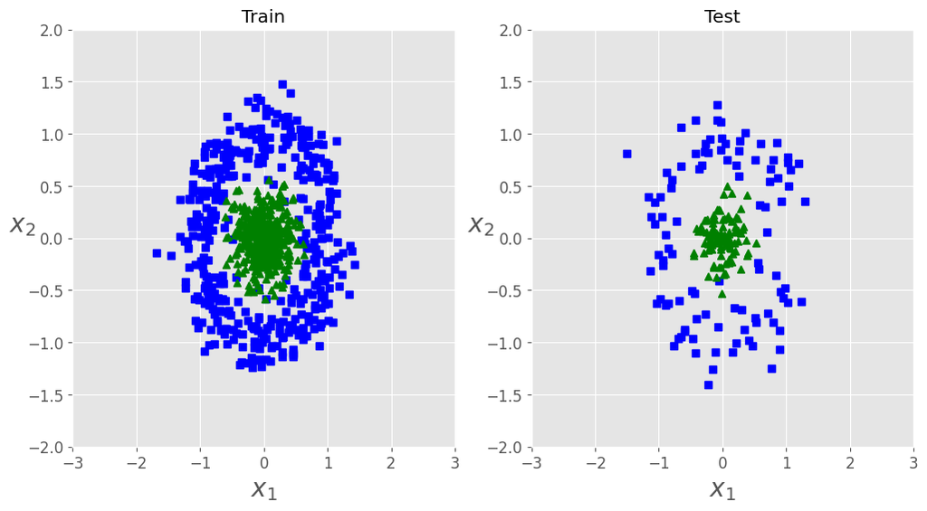

```python
axes_range = [-3, 3, -2, 2]
_, _ = plot_dataset(X_train, x_test, Y_train, y_test, axes_range)
```

This data set is clearly non-linearly separable, at least not at this domain. We should now use the `StratifiedKFold` class as in the previous tutorial with 3 splits and then we will use `GridSearchCV` to look for the best linear SVM among the different given C values for classification penalties. Use `Pipeline` to insert scaling and notice that the kernel should not be a string but rather a one-element list containing the adequate string for linear kernel.  
Again, we would look for the best estimator according to AUROC performance and for "running info" we would use `verbose=3`. Name the `GridSearchCV` as `svm_lin` and use `svm` string for the dictionary of `Pipeline`.

```python
n_splits = 3
skf = StratifiedKFold(n_splits=n_splits, random_state=10, shuffle=True)
```

```python
#C1
from sklearn.svm import SVC
from sklearn.model_selection import GridSearchCV, StratifiedKFold
from sklearn.pipeline import Pipeline
from sklearn.preprocessing import StandardScaler

svc = SVC(probability=True, random_state=336546)
C = np.array([0.001, 0.01, 1, 10, 100, 1000])
#--------------------------Impelment your code here:-------------------------------------
skf = StratifiedKFold(n_splits=3, shuffle=True, random_state=10)
pipeline = Pipeline([('scale', StandardScaler()), ('svm', svc)])
params = {'svm__C': C, 'svm__kernel': ['linear']}

svm_lin = GridSearchCV(estimator=pipeline, param_grid=params, scoring={'accuracy': 'accuracy', 'f1': 'f1', 'precision': 'precision', 'recall': 'recall', 'roc_auc': 'roc_auc'}, refit='roc_auc', return_train_score=True, cv=skf, verbose=3)
svm_lin.fit(X_train, Y_train)
#------------------------------------------------------------------------------------------
```

```
Fitting 3 folds for each of 6 candidates, totalling 18 fits
[CV 1/3] END svm__C=0.001, svm__kernel=linear; accuracy: (train=0.501, test=0.498) f1: (train=0.000, test=0.000) precision: (train=0.000, test=0.000) recall: (train=0.000, test=0.000) roc_auc: (train=0.525, test=0.439) total time=   0.0s
[CV 2/3] END svm__C=0.001, svm__kernel=linear; accuracy: (train=0.501, test=0.498) f1: (train=0.667, test=0.665) precision: (train=0.501, test=0.498) recall: (train=1.000, test=1.000) roc_auc: (train=0.515, test=0.485) total time=   0.0s
```

```
[CV 3/3] END svm__C=0.001, svm__kernel=linear; accuracy: (train=0.674, test=0.677) f1: (train=0.746, test=0.750) precision: (train=0.612, test=0.611) recall: (train=0.955, test=0.970) roc_auc: (train=0.517, test=0.479) total time=   0.0s
[CV 1/3] END svm__C=0.01, svm__kernel=linear; accuracy: (train=0.501, test=0.494) f1: (train=0.000, test=0.000) precision: (train=0.000, test=0.000) recall: (train=0.000, test=0.000) roc_auc: (train=0.526, test=0.439) total time=   0.0s
[CV 2/3] END svm__C=0.01, svm__kernel=linear; accuracy: (train=0.501, test=0.498) f1: (train=0.667, test=0.665) precision: (train=0.501, test=0.498) recall: (train=1.000, test=1.000) roc_auc: (train=0.515, test=0.485) total time=   0.0s
[CV 3/3] END svm__C=0.01, svm__kernel=linear; accuracy: (train=0.674, test=0.677) f1: (train=0.746, test=0.750) precision: (train=0.612, test=0.611) recall: (train=0.955, test=0.970) roc_auc: (train=0.517, test=0.479) total time=   0.0s
```

```
[CV 1/3] END svm__C=1.0, svm__kernel=linear; accuracy: (train=0.675, test=0.610) f1: (train=0.745, test=0.706) precision: (train=0.613, test=0.568) recall: (train=0.951, test=0.933) roc_auc: (train=0.524, test=0.440) total time=   0.0s
[CV 2/3] END svm__C=1.0, svm__kernel=linear; accuracy: (train=0.672, test=0.640) f1: (train=0.750, test=0.724) precision: (train=0.606, test=0.586) recall: (train=0.981, test=0.947) roc_auc: (train=0.514, test=0.488) total time=   0.0s
[CV 3/3] END svm__C=1.0, svm__kernel=linear; accuracy: (train=0.674, test=0.669) f1: (train=0.744, test=0.743) precision: (train=0.613, test=0.608) recall: (train=0.948, test=0.955) roc_auc: (train=0.520, test=0.476) total time=   0.0s
```

```
[CV 1/3] END svm__C=10.0, svm__kernel=linear; accuracy: (train=0.677, test=0.614) f1: (train=0.746, test=0.708) precision: (train=0.615, test=0.571) recall: (train=0.947, test=0.933) roc_auc: (train=0.524, test=0.439) total time=   0.0s
[CV 2/3] END svm__C=10.0, svm__kernel=linear; accuracy: (train=0.672, test=0.637) f1: (train=0.750, test=0.720) precision: (train=0.606, test=0.584) recall: (train=0.981, test=0.940) roc_auc: (train=0.514, test=0.488) total time=   0.0s
```

```
[CV 3/3] END svm__C=10.0, svm__kernel=linear; accuracy: (train=0.680, test=0.669) f1: (train=0.747, test=0.743) precision: (train=0.617, test=0.608) recall: (train=0.948, test=0.955) roc_auc: (train=0.519, test=0.477) total time=   0.0s
```

```
[CV 1/3] END svm__C=100.0, svm__kernel=linear; accuracy: (train=0.677, test=0.614) f1: (train=0.746, test=0.708) precision: (train=0.615, test=0.571) recall: (train=0.947, test=0.933) roc_auc: (train=0.524, test=0.439) total time=   0.3s
```

```
[CV 2/3] END svm__C=100.0, svm__kernel=linear; accuracy: (train=0.672, test=0.637) f1: (train=0.750, test=0.720) precision: (train=0.606, test=0.584) recall: (train=0.981, test=0.940) roc_auc: (train=0.514, test=0.488) total time=   0.3s
```

```
[CV 3/3] END svm__C=100.0, svm__kernel=linear; accuracy: (train=0.680, test=0.669) f1: (train=0.747, test=0.743) precision: (train=0.617, test=0.608) recall: (train=0.948, test=0.955) roc_auc: (train=0.519, test=0.477) total time=   0.3s
```

```
[CV 1/3] END svm__C=1000.0, svm__kernel=linear; accuracy: (train=0.677, test=0.614) f1: (train=0.746, test=0.708) precision: (train=0.615, test=0.571) recall: (train=0.947, test=0.933) roc_auc: (train=0.524, test=0.439) total time=   7.3s
```

```
[CV 2/3] END svm__C=1000.0, svm__kernel=linear; accuracy: (train=0.674, test=0.637) f1: (train=0.751, test=0.722) precision: (train=0.608, test=0.583) recall: (train=0.981, test=0.947) roc_auc: (train=0.514, test=0.488) total time=   7.2s
```

```
[CV 3/3] END svm__C=1000.0, svm__kernel=linear; accuracy: (train=0.680, test=0.669) f1: (train=0.747, test=0.743) precision: (train=0.617, test=0.608) recall: (train=0.948, test=0.955) roc_auc: (train=0.519, test=0.477) total time=   7.0s
```

```
GridSearchCV(cv=StratifiedKFold(n_splits=3, random_state=10, shuffle=True),
             estimator=Pipeline(steps=[('scale', StandardScaler()),
                                       ('svm',
                                        SVC(probability=True,
                                            random_state=336546))]),
             param_grid={'svm__C': array([1.e-03, 1.e-02, 1.e+00, 1.e+01, 1.e+02, 1.e+03]),
                         'svm__kernel': ['linear']},
             refit='roc_auc', return_train_score=True,
             scoring={'accuracy': 'accuracy', 'f1': 'f1',
                      'precision': 'precision', 'recall': 'recall',
                      'roc_auc': 'roc_auc'},
             verbose=3)
```

Choose the best linear model and name it as `best_svm_lin`. In addition, print the parameters adequate to the best classifier

```python
#C2
#--------------------------Impelment your code here:-------------------------------------
best_svm_lin = svm_lin.best_estimator_
print("Best parameters for linear SVM:", svm_lin.best_params_)
#-----------------------------------------------------------------------------------------
```

```
Best parameters for linear SVM: {'svm__C': np.float64(1.0), 'svm__kernel': 'linear'}
```

### Expected outpout:

[figure not shown]

Now let's look at the performances as a function of missclassification penalties:

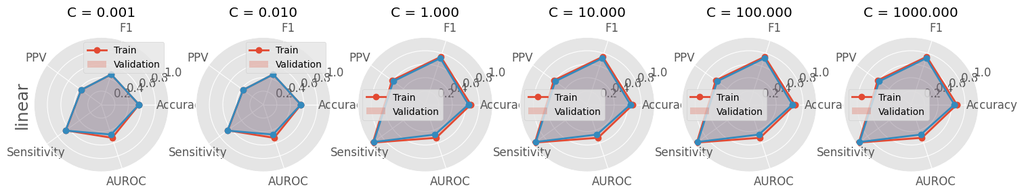

```python
clf_type = ['linear']
plot_radar(svm_lin, clf_type)
```

### Expected outpout:

[figure not shown]

And now, we would like to visualize the classification of our chosen estimator using `decision_function` method (used within `plot_predictions`).

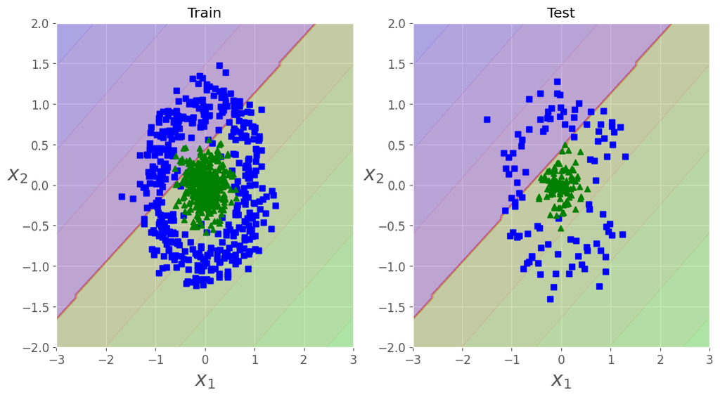

```python
axes_range = [-3, 3, -2, 2]
_, axs = plot_dataset(X_train, x_test, Y_train, y_test, axes_range)
plot_predictions(best_svm_lin, axs, axes_range)
```

### Expected outpout:

[figure not shown]

```python
from sklearn.metrics import confusion_matrix
calc_TN = lambda y_true, y_pred: confusion_matrix(y_true, y_pred)[0, 0]
calc_FP = lambda y_true, y_pred: confusion_matrix(y_true, y_pred)[0, 1]
calc_FN = lambda y_true, y_pred: confusion_matrix(y_true, y_pred)[1, 0]
calc_TP = lambda y_true, y_pred: confusion_matrix(y_true, y_pred)[1, 1]
```

Calculate the statistics and plot the confusion matrix as in previous tutorial.

```
Accuracy is 0.685
F1 is 0.759
PPV is 0.615
Sensitivity is 0.990
```

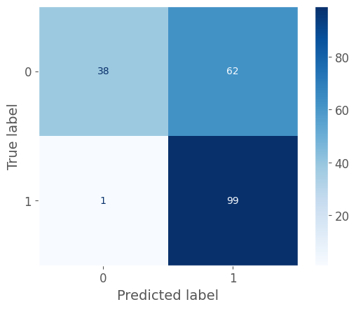

```
AUROC is 0.509
```

```python
#C3
from sklearn.metrics import accuracy_score, f1_score, precision_score, recall_score, roc_auc_score, ConfusionMatrixDisplay

y_pred_test = best_svm_lin.predict(x_test) #NOTICE NOT TO USE THE STANDARDIZED DATA.
y_pred_proba_test = best_svm_lin.predict_proba(x_test)
#--------------------------Impelment your code here:-------------------------------------
print('Accuracy is {:.3f}'.format(accuracy_score(y_test, y_pred_test)))
print('F1 is {:.3f}'.format(f1_score(y_test, y_pred_test)))
print('PPV is {:.3f}'.format(precision_score(y_test, y_pred_test)))
print('Sensitivity is {:.3f}'.format(recall_score(y_test, y_pred_test)))

ConfusionMatrixDisplay.from_estimator(best_svm_lin, x_test, y_test, cmap=plt.cm.Blues)
plt.grid(False)
plt.show()
#------------------------------------------------------------------------------------------
print('AUROC is {:.3f}'.format(roc_auc_score(y_test, y_pred_proba_test[:,1])))
```

### Expected outpout:

[figure not shown]

Now we would look for a **nonlinear** SVM calssifier. Use the kernels `rbf` and `poly`. For $\gamma$, use `auto` and `scale`. The order of the polynom should be 3 (so it won't take more than several minutes). Notice to use a single-element list for this.

```python
#C4
from sklearn.svm import SVC
from sklearn.model_selection import GridSearchCV, StratifiedKFold
from sklearn.pipeline import Pipeline
from sklearn.preprocessing import StandardScaler

svc = SVC(probability=True, random_state=336546)
C = np.array([1, 100, 1000])#, 10, 100, 1000])
#--------------------------Impelment your code here:-------------------------------------
skf = StratifiedKFold(n_splits=3, shuffle=True, random_state=10)
pipeline_nonlin = Pipeline([('scale', StandardScaler()), ('svm', svc)])
params_nonlin = {'svm__C': C, 'svm__kernel': ['rbf', 'poly'], 'svm__gamma': ['auto', 'scale'], 'svm__degree': [3]}

svm_nonlin = GridSearchCV(estimator=pipeline_nonlin, param_grid=params_nonlin, scoring={'accuracy': 'accuracy', 'f1': 'f1', 'precision': 'precision', 'recall': 'recall', 'roc_auc': 'roc_auc'}, refit='roc_auc', return_train_score=True, cv=skf, verbose=3)
svm_nonlin.fit(X_train, Y_train)
#-----------------------------------------------------------------------------------------
```

```
Fitting 3 folds for each of 12 candidates, totalling 36 fits
[CV 1/3] END svm__C=1, svm__degree=3, svm__gamma=auto, svm__kernel=rbf; accuracy: (train=0.983, test=0.978) f1: (train=0.983, test=0.978) precision: (train=0.974, test=0.964) recall: (train=0.992, test=0.993) roc_auc: (train=0.999, test=0.997) total time=   0.0s
[CV 2/3] END svm__C=1, svm__degree=3, svm__gamma=auto, svm__kernel=rbf; accuracy: (train=0.976, test=0.978) f1: (train=0.976, test=0.977) precision: (train=0.970, test=0.985) recall: (train=0.981, test=0.970) roc_auc: (train=0.998, test=0.998) total time=   0.0s
```

```
[CV 3/3] END svm__C=1, svm__degree=3, svm__gamma=auto, svm__kernel=rbf; accuracy: (train=0.981, test=0.974) f1: (train=0.981, test=0.974) precision: (train=0.974, test=0.970) recall: (train=0.989, test=0.977) roc_auc: (train=0.999, test=0.997) total time=   0.0s
[CV 1/3] END svm__C=1, svm__degree=3, svm__gamma=auto, svm__kernel=poly; accuracy: (train=0.602, test=0.588) f1: (train=0.715, test=0.709) precision: (train=0.556, test=0.549) recall: (train=1.000, test=1.000) roc_auc: (train=0.514, test=0.468) total time=   0.0s
```

```
[CV 2/3] END svm__C=1, svm__degree=3, svm__gamma=auto, svm__kernel=poly; accuracy: (train=0.623, test=0.596) f1: (train=0.727, test=0.711) precision: (train=0.571, test=0.552) recall: (train=1.000, test=1.000) roc_auc: (train=0.510, test=0.492) total time=   0.0s
```

```
[CV 3/3] END svm__C=1, svm__degree=3, svm__gamma=auto, svm__kernel=poly; accuracy: (train=0.581, test=0.564) f1: (train=0.704, test=0.696) precision: (train=0.544, test=0.534) recall: (train=1.000, test=1.000) roc_auc: (train=0.513, test=0.478) total time=   0.0s
[CV 1/3] END svm__C=1, svm__degree=3, svm__gamma=scale, svm__kernel=rbf; accuracy: (train=0.983, test=0.978) f1: (train=0.983, test=0.978) precision: (train=0.974, test=0.964) recall: (train=0.992, test=0.993) roc_auc: (train=0.999, test=0.997) total time=   0.0s
[CV 2/3] END svm__C=1, svm__degree=3, svm__gamma=scale, svm__kernel=rbf; accuracy: (train=0.976, test=0.978) f1: (train=0.976, test=0.977) precision: (train=0.970, test=0.985) recall: (train=0.981, test=0.970) roc_auc: (train=0.998, test=0.998) total time=   0.0s
[CV 3/3] END svm__C=1, svm__degree=3, svm__gamma=scale, svm__kernel=rbf; accuracy: (train=0.981, test=0.974) f1: (train=0.981, test=0.974) precision: (train=0.974, test=0.970) recall: (train=0.989, test=0.977) roc_auc: (train=0.999, test=0.997) total time=   0.0s
```

```
[CV 1/3] END svm__C=1, svm__degree=3, svm__gamma=scale, svm__kernel=poly; accuracy: (train=0.602, test=0.588) f1: (train=0.715, test=0.709) precision: (train=0.556, test=0.549) recall: (train=1.000, test=1.000) roc_auc: (train=0.514, test=0.468) total time=   0.0s
```

```
[CV 2/3] END svm__C=1, svm__degree=3, svm__gamma=scale, svm__kernel=poly; accuracy: (train=0.623, test=0.596) f1: (train=0.727, test=0.711) precision: (train=0.571, test=0.552) recall: (train=1.000, test=1.000) roc_auc: (train=0.510, test=0.492) total time=   0.0s
[CV 3/3] END svm__C=1, svm__degree=3, svm__gamma=scale, svm__kernel=poly; accuracy: (train=0.581, test=0.564) f1: (train=0.704, test=0.696) precision: (train=0.544, test=0.534) recall: (train=1.000, test=1.000) roc_auc: (train=0.513, test=0.478) total time=   0.0s
[CV 1/3] END svm__C=100, svm__degree=3, svm__gamma=auto, svm__kernel=rbf; accuracy: (train=0.987, test=0.966) f1: (train=0.987, test=0.967) precision: (train=0.985, test=0.963) recall: (train=0.989, test=0.970) roc_auc: (train=0.999, test=0.994) total time=   0.0s
```

```
[CV 2/3] END svm__C=100, svm__degree=3, svm__gamma=auto, svm__kernel=rbf; accuracy: (train=0.981, test=0.978) f1: (train=0.982, test=0.977) precision: (train=0.967, test=0.977) recall: (train=0.996, test=0.977) roc_auc: (train=0.998, test=0.998) total time=   0.0s
[CV 3/3] END svm__C=100, svm__degree=3, svm__gamma=auto, svm__kernel=rbf; accuracy: (train=0.983, test=0.970) f1: (train=0.983, test=0.970) precision: (train=0.981, test=0.963) recall: (train=0.985, test=0.977) roc_auc: (train=0.999, test=0.997) total time=   0.0s
```

```
[CV 1/3] END svm__C=100, svm__degree=3, svm__gamma=auto, svm__kernel=poly; accuracy: (train=0.604, test=0.588) f1: (train=0.716, test=0.709) precision: (train=0.558, test=0.549) recall: (train=1.000, test=1.000) roc_auc: (train=0.515, test=0.469) total time=   1.5s
```

```
[CV 2/3] END svm__C=100, svm__degree=3, svm__gamma=auto, svm__kernel=poly; accuracy: (train=0.623, test=0.596) f1: (train=0.727, test=0.711) precision: (train=0.571, test=0.552) recall: (train=1.000, test=1.000) roc_auc: (train=0.510, test=0.492) total time=   1.4s
```

```
[CV 3/3] END svm__C=100, svm__degree=3, svm__gamma=auto, svm__kernel=poly; accuracy: (train=0.581, test=0.560) f1: (train=0.704, test=0.695) precision: (train=0.544, test=0.532) recall: (train=1.000, test=1.000) roc_auc: (train=0.513, test=0.478) total time=   1.1s
[CV 1/3] END svm__C=100, svm__degree=3, svm__gamma=scale, svm__kernel=rbf; accuracy: (train=0.987, test=0.966) f1: (train=0.987, test=0.967) precision: (train=0.985, test=0.963) recall: (train=0.989, test=0.970) roc_auc: (train=0.999, test=0.994) total time=   0.0s
[CV 2/3] END svm__C=100, svm__degree=3, svm__gamma=scale, svm__kernel=rbf; accuracy: (train=0.981, test=0.978) f1: (train=0.982, test=0.977) precision: (train=0.967, test=0.977) recall: (train=0.996, test=0.977) roc_auc: (train=0.998, test=0.998) total time=   0.0s
[CV 3/3] END svm__C=100, svm__degree=3, svm__gamma=scale, svm__kernel=rbf; accuracy: (train=0.983, test=0.970) f1: (train=0.983, test=0.970) precision: (train=0.981, test=0.963) recall: (train=0.985, test=0.977) roc_auc: (train=0.999, test=0.997) total time=   0.0s
```

```
[CV 1/3] END svm__C=100, svm__degree=3, svm__gamma=scale, svm__kernel=poly; accuracy: (train=0.604, test=0.588) f1: (train=0.716, test=0.709) precision: (train=0.558, test=0.549) recall: (train=1.000, test=1.000) roc_auc: (train=0.515, test=0.469) total time=   1.6s
```

```
[CV 2/3] END svm__C=100, svm__degree=3, svm__gamma=scale, svm__kernel=poly; accuracy: (train=0.623, test=0.596) f1: (train=0.727, test=0.711) precision: (train=0.571, test=0.552) recall: (train=1.000, test=1.000) roc_auc: (train=0.510, test=0.492) total time=   1.0s
```

```
[CV 3/3] END svm__C=100, svm__degree=3, svm__gamma=scale, svm__kernel=poly; accuracy: (train=0.581, test=0.560) f1: (train=0.704, test=0.695) precision: (train=0.544, test=0.532) recall: (train=1.000, test=1.000) roc_auc: (train=0.513, test=0.478) total time=   0.9s
[CV 1/3] END svm__C=1000, svm__degree=3, svm__gamma=auto, svm__kernel=rbf; accuracy: (train=0.991, test=0.970) f1: (train=0.991, test=0.971) precision: (train=0.985, test=0.957) recall: (train=0.996, test=0.985) roc_auc: (train=0.999, test=0.978) total time=   0.0s
[CV 2/3] END svm__C=1000, svm__degree=3, svm__gamma=auto, svm__kernel=rbf; accuracy: (train=0.983, test=0.970) f1: (train=0.983, test=0.970) precision: (train=0.971, test=0.977) recall: (train=0.996, test=0.962) roc_auc: (train=0.994, test=0.996) total time=   0.0s
[CV 3/3] END svm__C=1000, svm__degree=3, svm__gamma=auto, svm__kernel=rbf; accuracy: (train=0.985, test=0.970) f1: (train=0.985, test=0.970) precision: (train=0.981, test=0.963) recall: (train=0.989, test=0.977) roc_auc: (train=0.999, test=0.992) total time=   0.0s
```

```
[CV 1/3] END svm__C=1000, svm__degree=3, svm__gamma=auto, svm__kernel=poly; accuracy: (train=0.604, test=0.588) f1: (train=0.716, test=0.709) precision: (train=0.558, test=0.549) recall: (train=1.000, test=1.000) roc_auc: (train=0.514, test=0.470) total time=  16.0s
```

```
[CV 2/3] END svm__C=1000, svm__degree=3, svm__gamma=auto, svm__kernel=poly; accuracy: (train=0.623, test=0.596) f1: (train=0.727, test=0.711) precision: (train=0.571, test=0.552) recall: (train=1.000, test=1.000) roc_auc: (train=0.510, test=0.492) total time=  38.9s
```

```
[CV 3/3] END svm__C=1000, svm__degree=3, svm__gamma=auto, svm__kernel=poly; accuracy: (train=0.581, test=0.560) f1: (train=0.704, test=0.695) precision: (train=0.544, test=0.532) recall: (train=1.000, test=1.000) roc_auc: (train=0.513, test=0.478) total time=  17.7s
[CV 1/3] END svm__C=1000, svm__degree=3, svm__gamma=scale, svm__kernel=rbf; accuracy: (train=0.991, test=0.970) f1: (train=0.991, test=0.971) precision: (train=0.985, test=0.957) recall: (train=0.996, test=0.985) roc_auc: (train=0.999, test=0.978) total time=   0.0s
[CV 2/3] END svm__C=1000, svm__degree=3, svm__gamma=scale, svm__kernel=rbf; accuracy: (train=0.983, test=0.970) f1: (train=0.983, test=0.970) precision: (train=0.971, test=0.977) recall: (train=0.996, test=0.962) roc_auc: (train=0.994, test=0.996) total time=   0.0s
[CV 3/3] END svm__C=1000, svm__degree=3, svm__gamma=scale, svm__kernel=rbf; accuracy: (train=0.985, test=0.970) f1: (train=0.985, test=0.970) precision: (train=0.981, test=0.963) recall: (train=0.989, test=0.977) roc_auc: (train=0.999, test=0.992) total time=   0.0s
```

```
[CV 1/3] END svm__C=1000, svm__degree=3, svm__gamma=scale, svm__kernel=poly; accuracy: (train=0.604, test=0.588) f1: (train=0.716, test=0.709) precision: (train=0.558, test=0.549) recall: (train=1.000, test=1.000) roc_auc: (train=0.514, test=0.470) total time=  15.3s
```

```
[CV 2/3] END svm__C=1000, svm__degree=3, svm__gamma=scale, svm__kernel=poly; accuracy: (train=0.623, test=0.596) f1: (train=0.727, test=0.711) precision: (train=0.571, test=0.552) recall: (train=1.000, test=1.000) roc_auc: (train=0.510, test=0.492) total time=  38.2s
```

```
[CV 3/3] END svm__C=1000, svm__degree=3, svm__gamma=scale, svm__kernel=poly; accuracy: (train=0.581, test=0.560) f1: (train=0.704, test=0.695) precision: (train=0.544, test=0.532) recall: (train=1.000, test=1.000) roc_auc: (train=0.513, test=0.478) total time=  17.5s
```

```
GridSearchCV(cv=StratifiedKFold(n_splits=3, random_state=10, shuffle=True),
             estimator=Pipeline(steps=[('scale', StandardScaler()),
                                       ('svm',
                                        SVC(probability=True,
                                            random_state=336546))]),
             param_grid={'svm__C': array([   1,  100, 1000]),
                         'svm__degree': [3], 'svm__gamma': ['auto', 'scale'],
                         'svm__kernel': ['rbf', 'poly']},
             refit='roc_auc', return_train_score=True,
             scoring={'accuracy': 'accuracy', 'f1': 'f1',
                      'precision': 'precision', 'recall': 'recall',
                      'roc_auc': 'roc_auc'},
             verbose=3)
```

Choose the best estimator and name it as `best_svm_nonlin`.

**Question:** *Which kernel do you think is more proper to use?*

```python
#C5
#--------------------------Impelment your code here:-------------------------------------
best_svm_nonlin = svm_nonlin.best_estimator_
print("Best parameters for non-linear SVM:", svm_nonlin.best_params_)
#------------------------------------------------------------------------------------------
```

```
Best parameters for non-linear SVM: {'svm__C': np.int64(1), 'svm__degree': 3, 'svm__gamma': 'auto', 'svm__kernel': 'rbf'}
```

### Expected outpout:

[figure not shown]

Now you can plot The performances as a function of missclassification penalties for different kernels and $\gamma$.

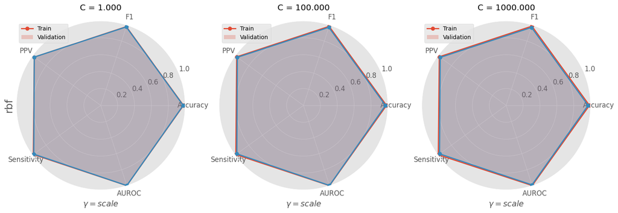

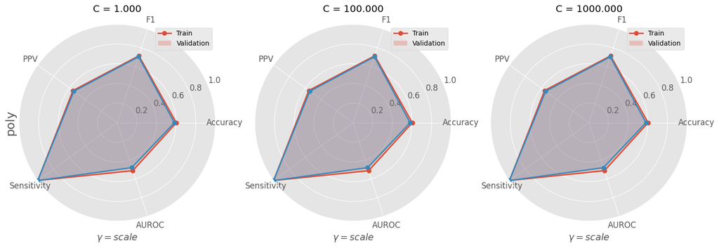

```python
clf_type = ['rbf', 'scale']
plot_radar(svm_nonlin, clf_type)
clf_type = ['poly', 'scale']
plot_radar(svm_nonlin, clf_type)
```

### Expected outpout:

[figure not shown]

Let's visualize the decision function upon our data:

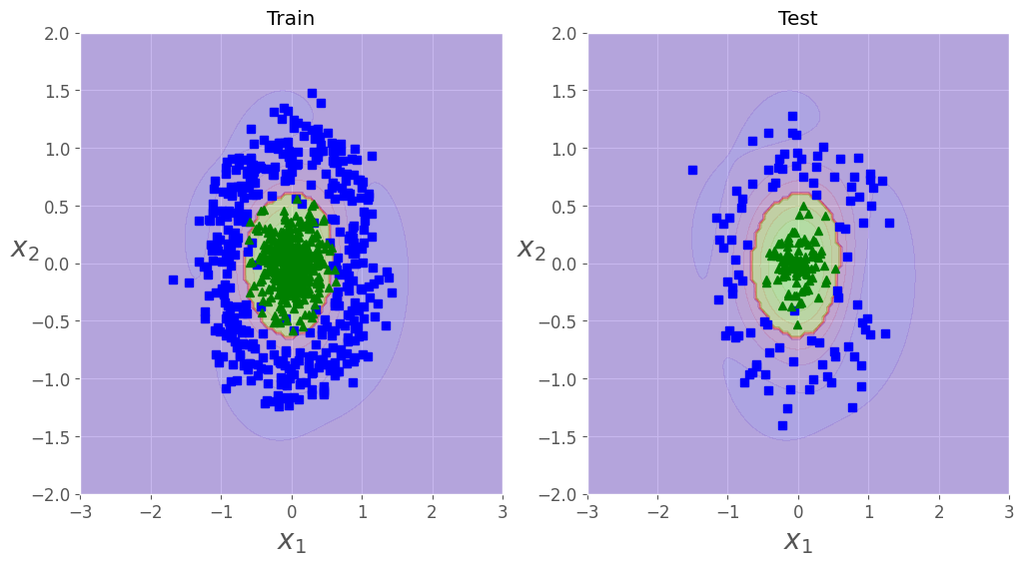

```python
_, axs = plot_dataset(X_train, x_test, Y_train, y_test, axes_range)
plot_predictions(best_svm_nonlin, axs, axes_range)
```

### Expected outpout:

[figure not shown]

Calculate the statistics and plot the confusion matrix as in previous tutorial.

```
Accuracy is 0.995
F1 is 0.995
PPV is 0.990
Sensitivity is 1.000
```

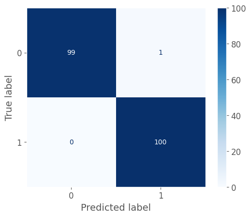

```
AUROC is 0.998
```

```python
#C6
from sklearn.metrics import accuracy_score, f1_score, precision_score, recall_score, roc_auc_score, ConfusionMatrixDisplay

y_pred_test = best_svm_nonlin.predict(x_test) #NOTICE NOT TO USE THE STANDARDIZED DATA.
y_pred_proba_test = best_svm_nonlin.predict_proba(x_test)
#--------------------------Impelment your code here:-------------------------------------
print('Accuracy is {:.3f}'.format(accuracy_score(y_test, y_pred_test)))
print('F1 is {:.3f}'.format(f1_score(y_test, y_pred_test)))
print('PPV is {:.3f}'.format(precision_score(y_test, y_pred_test)))
print('Sensitivity is {:.3f}'.format(recall_score(y_test, y_pred_test)))

ConfusionMatrixDisplay.from_estimator(best_svm_nonlin, x_test, y_test, cmap=plt.cm.Blues)
plt.grid(False)
plt.show()
#------------------------------------------------------------------------------------------
print('AUROC is {:.3f}'.format(roc_auc_score(y_test, y_pred_proba_test[:,1])))
```

### Expected outpout:

[figure not shown]

Here, we will only introduce a powerful classifier named *random forest* that was also used in the last part of *HW1*. Calculate the statistics and plot the confusion matrix as in previous tutorial.

```
Accuracy is 0.990
F1 is 0.990
PPV is 0.980
Sensitivity is 1.000
```

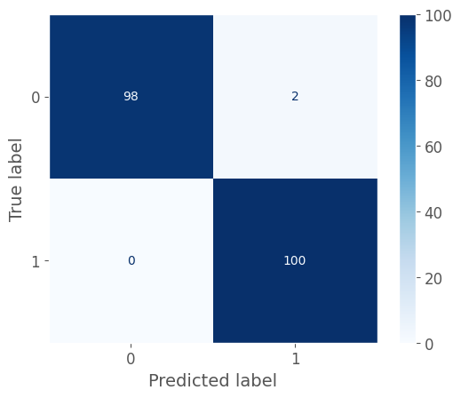

```
AUROC is 1.000
```

```python
#C7
from sklearn.metrics import accuracy_score, f1_score, precision_score, recall_score, roc_auc_score, ConfusionMatrixDisplay
from sklearn.ensemble import RandomForestClassifier
from sklearn.pipeline import Pipeline
from sklearn.preprocessing import StandardScaler

rfc = Pipeline(steps=[('scale', StandardScaler()), ('rfc', RandomForestClassifier(max_depth=4, random_state=336546, criterion='gini'))])
rfc.fit(X_train, Y_train)
y_pred_test = rfc.predict(x_test) #NOTICE NOT TO USE THE STANDARDIZED DATA.
y_pred_proba_test = rfc.predict_proba(x_test)
#--------------------------Impelment your code here:-------------------------------------
print('Accuracy is {:.3f}'.format(accuracy_score(y_test, y_pred_test)))
print('F1 is {:.3f}'.format(f1_score(y_test, y_pred_test)))
print('PPV is {:.3f}'.format(precision_score(y_test, y_pred_test)))
print('Sensitivity is {:.3f}'.format(recall_score(y_test, y_pred_test)))

ConfusionMatrixDisplay.from_estimator(rfc, x_test, y_test, cmap=plt.cm.Blues)
plt.grid(False)
plt.show()
#------------------------------------------------------------------------------------------
print('AUROC is {:.3f}'.format(roc_auc_score(y_test, y_pred_proba_test[:,1])))
```

### Expected outpout:

[figure not shown]

Finally, we will compare the classifiers according to AUROC.

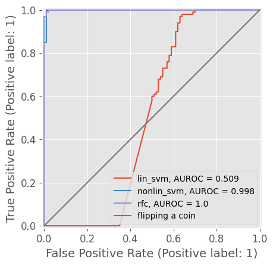

```python
classifiers = [best_svm_lin, best_svm_nonlin, rfc]
roc_score = []
plt.figure()
ax = plt.gca()
for clf in classifiers:
    RocCurveDisplay.from_estimator(clf, x_test, y_test, ax=ax)
    roc_score.append(np.round(roc_auc_score(y_test, clf.predict_proba(x_test)[:,1]), decimals=3))
ax.plot(np.linspace(0,1,x_test.shape[0]),np.linspace(0,1,x_test.shape[0]))
plt.legend(('lin_svm, AUROC = '+str(roc_score[0]),'nonlin_svm, AUROC = '+str(roc_score[1]),'rfc, AUROC = '+str(roc_score[2]),'flipping a coin'))
```

### Expected outpout:

[figure not shown]

#### *This tutorial was written by Moran Davoodi & Alon Begin with the assitance of Yuval Ben Sason & Kevin Kotzen*